# R Notebook

```r
library(tidyverse)
library(data.table)
source("~/Script repository/R scripting/Utility_Fns.R")
source( "~/Script repository/R scripting/Matrix_Fns.R" )
```

```r
TTseq_timecourse <- fread( "C:/Users/kayle/Box/Vertinolab/McKayla Ford/Projects/R-loops_Pausing/Sequence_based_analysis/Classing_by_Skew/Polenkowski_Timecourse_TTseq/TTseq_timecourse_skewclassed.txt.gz", header=TRUE, drop=c( 2,3,4,5,6,7,8,9,10,15,20,22,23,24,26 ) )
```

Let’s quantile by skew at tss and skew at 3’ CGI, independent of dist/prox, to see what we see. If we spot something we can always divide things up further. Then could quantile by prox dist difference.

Alright, TSS skew to start with.

```r
per0   <- quantile( TTseq_timecourse$TSS_skew, 0   )
per20  <- quantile( TTseq_timecourse$TSS_skew, 0.2 )
per40  <- quantile( TTseq_timecourse$TSS_skew, 0.4 )
per60  <- quantile( TTseq_timecourse$TSS_skew, 0.6 )
per80  <- quantile( TTseq_timecourse$TSS_skew, 0.8 )
per100 <- quantile( TTseq_timecourse$TSS_skew, 1.0 )

per0
```

```
       0%
-0.725283
```

```r
per20
```

```
       20%
-0.1015751
```

```r
per40
```

```
       40%
0.02086338
```

```r
per60
```

```
      60%
0.1176541
```

```r
per80
```

```
      80%
0.2239787
```

```r
per100
```

```
     100%
0.8092178
```

So now filter.

```r
TSS20per  <- TTseq_timecourse[ TSS_skew <= per20 ]
TSS40per  <- TTseq_timecourse[ TSS_skew <= per40 & TSS_skew > per20 ]
TSS60per  <- TTseq_timecourse[ TSS_skew <= per60 & TSS_skew > per40 ]
TSS80per  <- TTseq_timecourse[ TSS_skew <= per80 & TSS_skew > per60 ]
TSS100per <- TTseq_timecourse[ TSS_skew  > per80 ]
```

oh let’s check how many dist and prox in each?

```r
print( "20th percentile dist vs prox" )
```

```
[1] "20th percentile dist vs prox"
```

```r
dim( TSS20per[ simple_skew_class == "Dist"] )
```

```
[1] 36032   415
```

```r
dim( TSS20per[ simple_skew_class == "Prox"] )
```

```
[1] 5888  415
```

```r
print( "40th percentile dist vs prox" )
```

```
[1] "40th percentile dist vs prox"
```

```r
dim( TSS40per[ simple_skew_class == "Dist"] )
```

```
[1] 27008   415
```

```r
dim( TSS40per[ simple_skew_class == "Prox"] )
```

```
[1] 14896   415
```

```r
print( "60th percentile dist vs prox" )
```

```
[1] "60th percentile dist vs prox"
```

```r
dim( TSS60per[ simple_skew_class == "Dist"] )
```

```
[1] 19200   415
```

```r
dim( TSS60per[ simple_skew_class == "Prox"] )
```

```
[1] 22704   415
```

```r
print( "80th percentile dist vs prox" )
```

```
[1] "80th percentile dist vs prox"
```

```r
dim( TSS80per[ simple_skew_class == "Dist"] )
```

```
[1] 12320   415
```

```r
dim( TSS80per[ simple_skew_class == "Prox"] )
```

```
[1] 29584   415
```

```r
print( "100th percentile dist vs prox" )
```

```
[1] "100th percentile dist vs prox"
```

```r
dim( TSS100per[ simple_skew_class == "Dist"] )
```

```
[1] 5216  415
```

```r
dim( TSS100per[ simple_skew_class == "Prox"] )
```

```
[1] 36688   415
```

Great. Now I need to pivot and merge. (keep original tab potentially to compare to other tabs)

```r
perlist <- list( TSS20per, TSS40per, TSS60per, TSS80per, TSS100per )

nlist <- list( 1:5 )

for ( per in seq_along( perlist ) ) {
    tmptab <- perlist[[per]][, c( 12:412, 414:415 ) ] #removed class used for now
    long_tab <- melt( tmptab, na.rm = TRUE, id.vars = c( "loc", "condition", "time" ) )
    nlist[[per]] <- long_tab[, .(mean_score = mean(value)), by = list(variable, loc, condition, time )]
}

rm( perlist )
```

(keep original IDs potentially to compare to other tabs)

```r
TSS20perIDs  <- TSS20per$uniq_id
TSS40perIDs  <- TSS40per$uniq_id
TSS60perIDs  <- TSS60per$uniq_id
TSS80perIDs  <- TSS80per$uniq_id
TSS100perIDs <- TSS100per$uniq_id

rm( TSS20per, TSS40per, TSS60per, TSS80per, TSS100per )
```

```r
nlist[[1]]$perc <- "20perc_TSS_skew"
nlist[[2]]$perc <- "40perc_TSS_skew"
nlist[[3]]$perc <- "60perc_TSS_skew"
nlist[[4]]$perc <- "80perc_TSS_skew"
nlist[[5]]$perc <- "100perc_TSS_skew"

TSS_skew_quant <- do.call( rbind, nlist )
```

Alright, need to fix the bin names (. is currently representing -, and everything is prefixed by an X)

```r
colnames( TSS_skew_quant )[1] <- "Bins"
TSS_skew_quant$Bins <- sub( "^X", "", TSS_skew_quant$Bins )
TSS_skew_quant$Bins <- sub( "^\\.", "-", TSS_skew_quant$Bins )
TSS_skew_quant$Bins <- as.numeric( TSS_skew_quant$Bins )
TSS_skew_quant$time <- as.character( TSS_skew_quant$time )
```

```r
mytheme <- theme(
  panel.background = element_rect( fill = "white" ),
  text = element_text( color = "black", face = "bold", family = "sans" ),
  axis.text = element_text( color = "black" ),
  axis.ticks = element_line( color = "black" ),
  plot.margin = unit( c( 0.25, 0.25, 0.25, 0.25 ), "cm" ),
  plot.title = element_text( vjust = 2 ),
  panel.grid.major = element_blank(),
  panel.grid.minor = element_blank(),
  axis.title.y = element_text( vjust = 0 ),
  axis.title.x = element_text( vjust = 0 ),
  panel.border = element_blank(),
  axis.line = element_line()
)
```

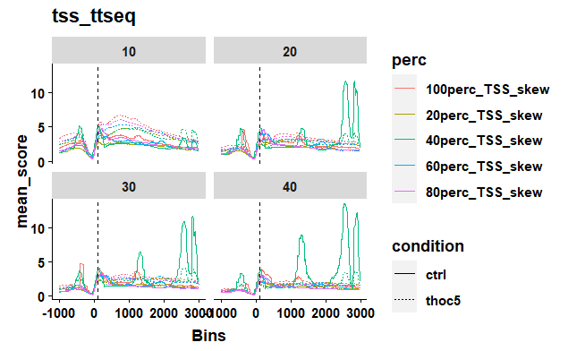

```r
geom1_TSS_skew_quant <- TSS_skew_quant |>
  filter( loc == "TSS" ) |>
  ggplot( aes( x = Bins, y = mean_score, color = perc, linetype = condition)) +
      geom_line() +
      mytheme +
      ggtitle(label="tss_ttseq") +
  facet_wrap(~time) +
  geom_vline(xintercept = 100, linetype = "dashed", color = "Black")
geom1_TSS_skew_quant
```

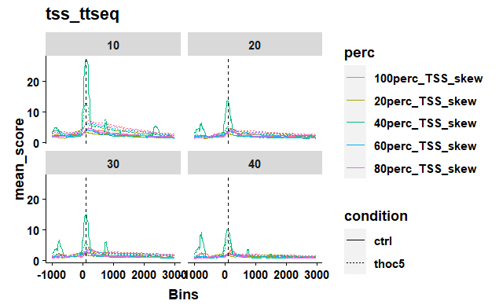

```r
geom2_TSS_skew_quant <- TSS_skew_quant |>
  filter( loc == "CGI" ) |>
  ggplot( aes( x = Bins, y = mean_score, color = perc, linetype = condition)) +
      geom_line() +
      mytheme +
      ggtitle(label="tss_ttseq") +
  facet_wrap(~time) +
  geom_vline(xintercept = 100, linetype = "dashed", color = "Black")
geom2_TSS_skew_quant
```

Yes, same effect.

Okay, what about skew at the 3’ edge? (I want to look at CGI length but let’s go through this progressively.)

```r
per0   <- quantile( TTseq_timecourse$CGI3_skew, 0   )
per20  <- quantile( TTseq_timecourse$CGI3_skew, 0.2 )
per40  <- quantile( TTseq_timecourse$CGI3_skew, 0.4 )
per60  <- quantile( TTseq_timecourse$CGI3_skew, 0.6 )
per80  <- quantile( TTseq_timecourse$CGI3_skew, 0.8 )
per100 <- quantile( TTseq_timecourse$CGI3_skew, 1.0 )

per0
```

```
        0%
-0.7506731
```

```r
per20
```

```
       20%
-0.1388058
```

```r
per40
```

```
         40%
-0.006335618
```

```r
per60
```

```
      60%
0.1025072
```

```r
per80
```

```
      80%
0.2275049
```

```r
per100
```

```
     100%
0.7970938
```

So now filter.

```r
CGI20per  <- TTseq_timecourse[ CGI3_skew <= per20 ]
CGI40per  <- TTseq_timecourse[ CGI3_skew <= per40 & CGI3_skew > per20 ]
CGI60per  <- TTseq_timecourse[ CGI3_skew <= per60 & CGI3_skew > per40 ]
CGI80per  <- TTseq_timecourse[ CGI3_skew <= per80 & CGI3_skew > per60 ]
CGI100per <- TTseq_timecourse[ CGI3_skew  > per80 ]
```

```r
print( "20th percentile dist vs prox" )
```

```
[1] "20th percentile dist vs prox"
```

```r
dim( CGI20per[ simple_skew_class == "Dist"] )
```

```
[1] 2928  415
```

```r
dim( CGI20per[ simple_skew_class == "Prox"] )
```

```
[1] 38992   415
```

```r
print( "40th percentile dist vs prox" )
```

```
[1] "40th percentile dist vs prox"
```

```r
dim( CGI40per[ simple_skew_class == "Dist"] )
```

```
[1] 10640   415
```

```r
dim( CGI40per[ simple_skew_class == "Prox"] )
```

```
[1] 31264   415
```

```r
print( "60th percentile dist vs prox" )
```

```
[1] "60th percentile dist vs prox"
```

```r
dim( CGI60per[ simple_skew_class == "Dist"] )
```

```
[1] 19824   415
```

```r
dim( CGI60per[ simple_skew_class == "Prox"] )
```

```
[1] 22080   415
```

```r
print( "80th percentile dist vs prox" )
```

```
[1] "80th percentile dist vs prox"
```

```r
dim( CGI80per[ simple_skew_class == "Dist"] )
```

```
[1] 28720   415
```

```r
dim( CGI80per[ simple_skew_class == "Prox"] )
```

```
[1] 13184   415
```

```r
print( "100th percentile dist vs prox" )
```

```
[1] "100th percentile dist vs prox"
```

```r
dim( CGI100per[ simple_skew_class == "Dist"] )
```

```
[1] 37664   415
```

```r
dim( CGI100per[ simple_skew_class == "Prox"] )
```

```
[1] 4240  415
```

```r
perlist <- list( CGI20per, CGI40per, CGI60per, CGI80per, CGI100per )

nlist <- list( 1:5 )

for ( per in seq_along( perlist ) ) {
    tmptab <- perlist[[per]][, c( 12:412, 414:415 ) ] #removed class used for now
    long_tab <- melt( tmptab, na.rm = TRUE, id.vars = c( "loc", "condition", "time" ) )
    nlist[[per]] <- long_tab[, .(mean_score = mean(value)), by = list(variable, loc, condition, time )]
}

rm( perlist )
```

```r
CGI20perIDs  <- CGI20per$uniq_id
CGI40perIDs  <- CGI40per$uniq_id
CGI60perIDs  <- CGI60per$uniq_id
CGI80perIDs  <- CGI80per$uniq_id
CGI100perIDs <- CGI100per$uniq_id

rm( CGI20per, CGI40per, CGI60per, CGI80per, CGI100per )
```

```r
nlist[[1]]$perc <- "20perc_CGI_skew"
nlist[[2]]$perc <- "40perc_CGI_skew"
nlist[[3]]$perc <- "60perc_CGI_skew"
nlist[[4]]$perc <- "80perc_CGI_skew"
nlist[[5]]$perc <- "100perc_CGI_skew"

CGI_skew_quant <- do.call( rbind, nlist )
```

```r
colnames( CGI_skew_quant )[1] <- "Bins"
CGI_skew_quant$Bins <- sub( "^X", "", CGI_skew_quant$Bins )
CGI_skew_quant$Bins <- sub( "^\\.", "-", CGI_skew_quant$Bins )
CGI_skew_quant$Bins <- as.numeric( CGI_skew_quant$Bins )
CGI_skew_quant$time <- as.character( CGI_skew_quant$time )
```

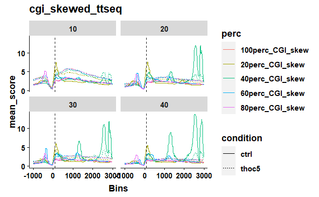

```r
geom1_CGI_skew_quant <- CGI_skew_quant |>
  filter( loc == "TSS" ) |>
  ggplot( aes( x = Bins, y = mean_score, color = perc, linetype = condition)) +
      geom_line() +
      mytheme +
      ggtitle(label="cgi_skewed_ttseq") +
  facet_wrap(~time) +
  geom_vline(xintercept = 100, linetype = "dashed", color = "Black")
geom1_CGI_skew_quant
```

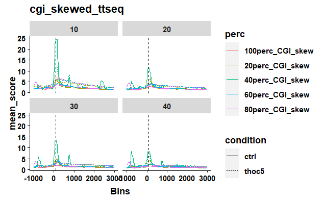

```r
geom2_CGI_skew_quant <- CGI_skew_quant |>
  filter( loc == "CGI" ) |>
  ggplot( aes( x = Bins, y = mean_score, color = perc, linetype = condition)) +
      geom_line() +
      mytheme +
      ggtitle(label="cgi_skewed_ttseq") +
  facet_wrap(~time) +
  geom_vline(xintercept = 100, linetype = "dashed", color = "Black")
geom2_CGI_skew_quant
```

Same deal. One last relevant skew one before moving on to distance to CGI edge and TTseq signal. (There is a pattern, but ‘it has moderate skew’ isn’t really an actionable pattern.)

```r
TTseq_timecourse$dif <- TTseq_timecourse$TSS_skew - TTseq_timecourse$CGI3_skew
per0   <- quantile( TTseq_timecourse$dif, 0   )
per20  <- quantile( TTseq_timecourse$dif, 0.2 )
per40  <- quantile( TTseq_timecourse$dif, 0.4 )
per60  <- quantile( TTseq_timecourse$dif, 0.6 )
per80  <- quantile( TTseq_timecourse$dif, 0.8 )
per100 <- quantile( TTseq_timecourse$dif, 1.0 )

per0
```

```
       0%
-1.222253
```

```r
per20
```

```
       20%
-0.2202034
```

```r
per40
```

```
       40%
-0.0574928
```

```r
per60
```

```
       60%
0.08795618
```

```r
per80
```

```
      80%
0.2563772
```

```r
per100
```

```
    100%
1.129856
```

So now filter.

```r
dif20per  <- TTseq_timecourse[ dif <= per20 ]
dif40per  <- TTseq_timecourse[ dif <= per40 & dif > per20 ]
dif60per  <- TTseq_timecourse[ dif <= per60 & dif > per40 ]
dif80per  <- TTseq_timecourse[ dif <= per80 & dif > per60 ]
dif100per <- TTseq_timecourse[ dif  > per80 ]
```

```r
print( "20th percentile dist vs prox" )
```

```
[1] "20th percentile dist vs prox"
```

```r
dim( dif20per[ simple_skew_class == "Dist"] )
```

```
[1] 41920   416
```

```r
dim( dif20per[ simple_skew_class == "Prox"] )
```

```
[1]   0 416
```

```r
print( "40th percentile dist vs prox" )
```

```
[1] "40th percentile dist vs prox"
```

```r
dim( dif40per[ simple_skew_class == "Dist"] )
```

```
[1] 41904   416
```

```r
dim( dif40per[ simple_skew_class == "Prox"] )
```

```
[1]   0 416
```

```r
print( "60th percentile dist vs prox" )
```

```
[1] "60th percentile dist vs prox"
```

```r
dim( dif60per[ simple_skew_class == "Dist"] )
```

```
[1] 15952   416
```

```r
dim( dif60per[ simple_skew_class == "Prox"] )
```

```
[1] 25968   416
```

```r
print( "80th percentile dist vs prox" )
```

```
[1] "80th percentile dist vs prox"
```

```r
dim( dif80per[ simple_skew_class == "Dist"] )
```

```
[1]   0 416
```

```r
dim( dif80per[ simple_skew_class == "Prox"] )
```

```
[1] 41888   416
```

```r
print( "100th percentile dist vs prox" )
```

```
[1] "100th percentile dist vs prox"
```

```r
dim( dif100per[ simple_skew_class == "Dist"] )
```

```
[1]   0 416
```

```r
dim( dif100per[ simple_skew_class == "Prox"] )
```

```
[1] 41904   416
```

```r
perlist <- list( dif20per, dif40per, dif60per, dif80per, dif100per )

nlist <- list( 1:5 )

for ( per in seq_along( perlist ) ) {
    tmptab <- perlist[[per]][, c( 12:412, 414:415 ) ] #removed class used for now
    long_tab <- melt( tmptab, na.rm = TRUE, id.vars = c( "loc", "condition", "time" ) )
    nlist[[per]] <- long_tab[, .(mean_score = mean(value)), by = list(variable, loc, condition, time )]
}

rm( perlist )
```

```r
dif20perIDs  <- dif20per$uniq_id
dif40perIDs  <- dif40per$uniq_id
dif60perIDs  <- dif60per$uniq_id
dif80perIDs  <- dif80per$uniq_id
dif100perIDs <- dif100per$uniq_id

rm( dif20per, dif40per, dif60per, dif80per, dif100per )
```

```r
nlist[[1]]$perc <- "20perc_dif_skew"
nlist[[2]]$perc <- "40perc_dif_skew"
nlist[[3]]$perc <- "60perc_dif_skew"
nlist[[4]]$perc <- "80perc_dif_skew"
nlist[[5]]$perc <- "100perc_dif_skew"

dif_skew_quant <- do.call( rbind, nlist )
```

```r
colnames( dif_skew_quant )[1] <- "Bins"
dif_skew_quant$Bins <- sub( "^X", "", dif_skew_quant$Bins )
dif_skew_quant$Bins <- sub( "^\\.", "-", dif_skew_quant$Bins )
dif_skew_quant$Bins <- as.numeric( dif_skew_quant$Bins )
dif_skew_quant$time <- as.character( dif_skew_quant$time )
```

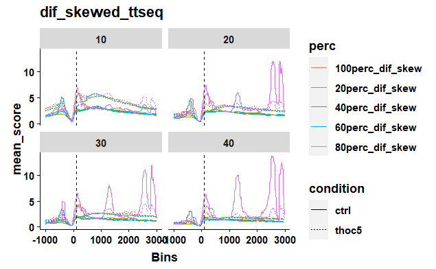

```r
geom1_dif_skew_quant <- dif_skew_quant |>
  filter( loc == "TSS" ) |>
  ggplot( aes( x = Bins, y = mean_score, color = perc, linetype = condition)) +
      geom_line() +
      mytheme +
      ggtitle(label="dif_skewed_ttseq") +
  facet_wrap(~time) +
  geom_vline(xintercept = 100, linetype = "dashed", color = "Black")
geom1_dif_skew_quant
```

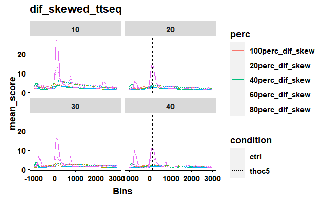

```r
geom2_dif_skew_quant <- dif_skew_quant |>
  filter( loc == "CGI" ) |>
  ggplot( aes( x = Bins, y = mean_score, color = perc, linetype = condition)) +
      geom_line() +
      mytheme +
      ggtitle(label="dif_skewed_ttseq") +
  facet_wrap(~time) +
  geom_vline(xintercept = 100, linetype = "dashed", color = "Black")
geom2_dif_skew_quant
```

Hmm. So it’s not the strongest difference that shows the waveform, it’s the second strongest. Which is still all prox.

```r
per0   <- quantile( TTseq_timecourse$TSS_3prime, 0   )
per20  <- quantile( TTseq_timecourse$TSS_3prime, 0.2 )
per40  <- quantile( TTseq_timecourse$TSS_3prime, 0.4 )
per60  <- quantile( TTseq_timecourse$TSS_3prime, 0.6 )
per80  <- quantile( TTseq_timecourse$TSS_3prime, 0.8 )
per100 <- quantile( TTseq_timecourse$TSS_3prime, 1.0 )

per0
```

```
 0%
150
```

```r
per20
```

```
20%
319
```

```r
per40
```

```
40%
459
```

```r
per60
```

```
60%
629
```

```r
per80
```

```
80%
916
```

```r
per100
```

```
 100%
10224
```

```r
len20per  <- TTseq_timecourse[ TSS_3prime <= per20 ]
len40per  <- TTseq_timecourse[ TSS_3prime <= per40 & TSS_3prime > per20 ]
len60per  <- TTseq_timecourse[ TSS_3prime <= per60 & TSS_3prime > per40 ]
len80per  <- TTseq_timecourse[ TSS_3prime <= per80 & TSS_3prime > per60 ]
len100per <- TTseq_timecourse[ TSS_3prime  > per80 ]
```

```r
print( "20th percentile dist vs prox" )
```

```
[1] "20th percentile dist vs prox"
```

```r
dim( len20per[ simple_skew_class == "Dist"] )
```

```
[1] 19488   416
```

```r
dim( len20per[ simple_skew_class == "Prox"] )
```

```
[1] 22448   416
```

```r
print( "40th percentile dist vs prox" )
```

```
[1] "40th percentile dist vs prox"
```

```r
dim( len40per[ simple_skew_class == "Dist"] )
```

```
[1] 18848   416
```

```r
dim( len40per[ simple_skew_class == "Prox"] )
```

```
[1] 23104   416
```

```r
print( "60th percentile dist vs prox" )
```

```
[1] "60th percentile dist vs prox"
```

```r
dim( len60per[ simple_skew_class == "Dist"] )
```

```
[1] 19200   416
```

```r
dim( len60per[ simple_skew_class == "Prox"] )
```

```
[1] 22768   416
```

```r
print( "80th percentile dist vs prox" )
```

```
[1] "80th percentile dist vs prox"
```

```r
dim( len80per[ simple_skew_class == "Dist"] )
```

```
[1] 20512   416
```

```r
dim( len80per[ simple_skew_class == "Prox"] )
```

```
[1] 21296   416
```

```r
print( "100th percentile dist vs prox" )
```

```
[1] "100th percentile dist vs prox"
```

```r
dim( len100per[ simple_skew_class == "Dist"] )
```

```
[1] 21728   416
```

```r
dim( len100per[ simple_skew_class == "Prox"] )
```

```
[1] 20144   416
```

```r
perlist <- list( len20per, len40per, len60per, len80per, len100per )

nlist <- list( 1:5 )

for ( per in seq_along( perlist ) ) {
    tmptab <- perlist[[per]][, c( 12:412, 414:415 ) ] #removed class used for now
    long_tab <- melt( tmptab, na.rm = TRUE, id.vars = c( "loc", "condition", "time" ) )
    nlist[[per]] <- long_tab[, .(mean_score = mean(value)), by = list(variable, loc, condition, time )]
}

rm( perlist )
```

```r
len20perIDs  <- len20per$uniq_id
len40perIDs  <- len40per$uniq_id
len60perIDs  <- len60per$uniq_id
len80perIDs  <- len80per$uniq_id
len100perIDs <- len100per$uniq_id

rm( len20per, len40per, len60per, len80per, len100per )
```

```r
nlist[[1]]$perc <- "20perc_len"
nlist[[2]]$perc <- "40perc_len"
nlist[[3]]$perc <- "60perc_len"
nlist[[4]]$perc <- "80perc_len"
nlist[[5]]$perc <- "100perc_len"

len_quant <- do.call( rbind, nlist )
```

```r
colnames( len_quant )[1] <- "Bins"
len_quant$Bins <- sub( "^X", "", len_quant$Bins )
len_quant$Bins <- sub( "^\\.", "-", len_quant$Bins )
len_quant$Bins <- as.numeric( len_quant$Bins )
len_quant$time <- as.character( len_quant$time )
```

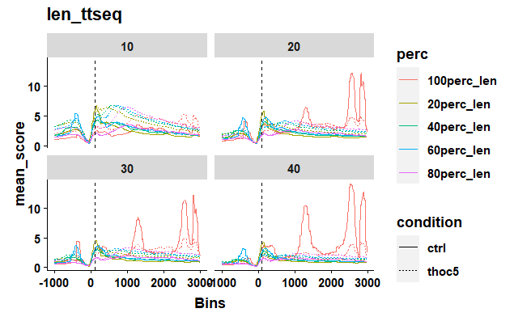

```r
geom1_len_quant <- len_quant |>
  filter( loc == "TSS" ) |>
  ggplot( aes( x = Bins, y = mean_score, color = perc, linetype = condition)) +
      geom_line() +
      mytheme +
      ggtitle(label="len_ttseq") +
  facet_wrap(~time) +
  geom_vline(xintercept = 100, linetype = "dashed", color = "Black")
geom1_len_quant
```

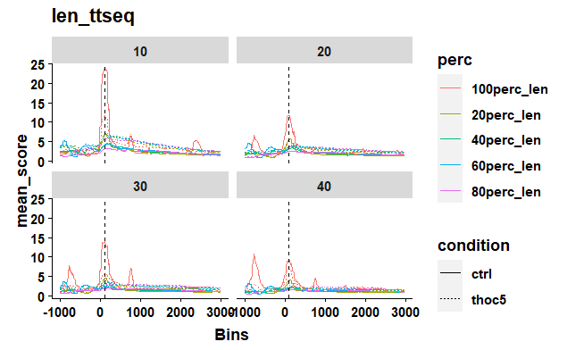

```r
geom2_len_quant <- len_quant |>
  filter( loc == "CGI" ) |>
  ggplot( aes( x = Bins, y = mean_score, color = perc, linetype = condition)) +
      geom_line() +
      mytheme +
      ggtitle(label="len_ttseq") +
  facet_wrap(~time) +
  geom_vline(xintercept = 100, linetype = "dashed", color = "Black")
geom2_len_quant
```

Well, isn’t that interesting? There’s a lot to unpack there.

Maybe split out by condition so they’re easier to see. Then I’m interested in if the skew class is relevant on top of this. (which means I’ll need to re-summarize the values.)

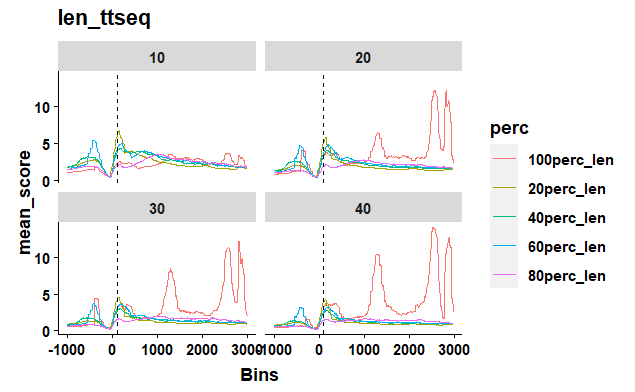

```r
geom1_len_quant <- len_quant |>
  filter( loc == "TSS" & condition == "ctrl") |>
  ggplot( aes( x = Bins, y = mean_score, color = perc)) +
      geom_line() +
      mytheme +
      ggtitle(label="len_ttseq") +
  facet_wrap(~time) +
  geom_vline(xintercept = 100, linetype = "dashed", color = "Black")
geom1_len_quant
```

The longest CGI quantile is the one with both the highest peaks (why?) and the downstream pattern. all the other quantiles are shorter than 1kb.

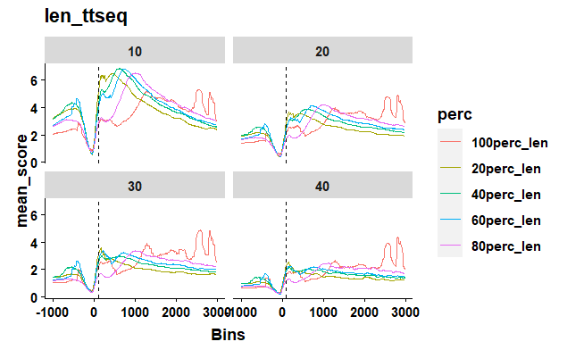

```r
geom2_len_quant <- len_quant |>
  filter( loc == "TSS" & condition == "thoc5") |>
  ggplot( aes( x = Bins, y = mean_score, color = perc)) +
      geom_line() +
      mytheme +
      ggtitle(label="len_ttseq") +
  facet_wrap(~time) +
  geom_vline(xintercept = 100, linetype = "dashed", color = "Black")
geom2_len_quant
```

There is a clear change in behavior at the CpG island edge when you knock Thoc5 out. They’re staggered from shortest to longest, and the longest still has a bit of the downstream peaks but it’s faded quite a bit.

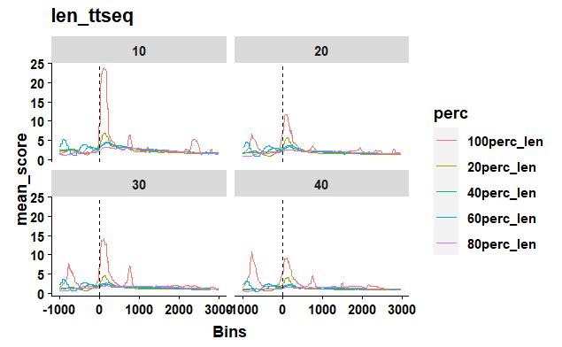

```r
geom3_len_quant <- len_quant |>
  filter( loc == "CGI" & condition == "ctrl") |>
  ggplot( aes( x = Bins, y = mean_score, color = perc)) +
      geom_line() +
      mytheme +
      ggtitle(label="len_ttseq") +
  facet_wrap(~time) +
  geom_vline(xintercept = 0, linetype = "dashed", color = "Black")
geom3_len_quant
```

This part I don’t understand. Why would only the longest CGI have this pattern at the edge? If anything I’d expect bleedthrough of TSS-associated signal in the short ones. Although to be fair, I do need to keep in mind that a lot of the shortest stuff is eliminated in TTseq, and… Well, actually. If tx normally moves at over a KB a minute, maybe the long CGI are the only ones where I’m going to be able to see any effect anyway? Not sure.

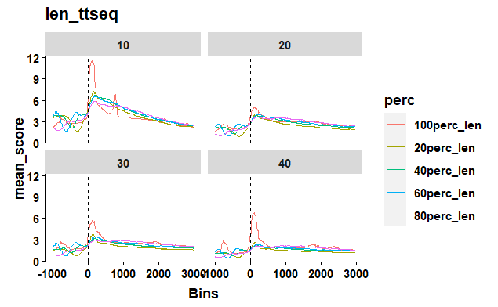

```r
geom4_len_quant <- len_quant |>
  filter( loc == "CGI" & condition == "thoc5") |>
  ggplot( aes( x = Bins, y = mean_score, color = perc)) +
      geom_line() +
      mytheme +
      ggtitle(label="len_ttseq") +
  facet_wrap(~time) +
  geom_vline(xintercept = 0, linetype = "dashed", color = "Black")
geom4_len_quant
```

At a bit of a loss for words with this one, TBH. Not sure what to think of it.

With prox/dist:

```r
len20per  <- TTseq_timecourse[ TSS_3prime <= per20 ]
len40per  <- TTseq_timecourse[ TSS_3prime <= per40 & TSS_3prime > per20 ]
len60per  <- TTseq_timecourse[ TSS_3prime <= per60 & TSS_3prime > per40 ]
len80per  <- TTseq_timecourse[ TSS_3prime <= per80 & TSS_3prime > per60 ]
len100per <- TTseq_timecourse[ TSS_3prime  > per80 ]
```

```r
perlist <- list( len20per, len40per, len60per, len80per, len100per )

nlist <- list( 1:5 )

for ( per in seq_along( perlist ) ) {
    tmptab <- perlist[[per]][, c( 12:415 ) ]
    long_tab <- melt( tmptab, na.rm = TRUE, id.vars = c( "loc", "condition", "time", "class_used" ) )
    nlist[[per]] <- long_tab[, .(mean_score = mean(value)), by = list(variable, loc, condition, time, class_used )]
}

rm( perlist )
```

```r
nlist[[1]]$perc <- "20perc_len"
nlist[[2]]$perc <- "40perc_len"
nlist[[3]]$perc <- "60perc_len"
nlist[[4]]$perc <- "80perc_len"
nlist[[5]]$perc <- "100perc_len"

len_quant <- do.call( rbind, nlist )
```

```r
colnames( len_quant )[1] <- "Bins"
len_quant$Bins <- sub( "^X", "", len_quant$Bins )
len_quant$Bins <- sub( "^\\.", "-", len_quant$Bins )
len_quant$Bins <- as.numeric( len_quant$Bins )
len_quant$time <- as.character( len_quant$time )
```

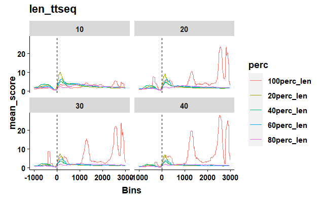

```r
geom5_len_quant <- len_quant |>
  filter( loc == "TSS" & condition == "ctrl" & class_used == "prox") |>
  ggplot( aes( x = Bins, y = mean_score, color = perc)) +
      geom_line() +
      mytheme +
      ggtitle(label="len_ttseq") +
  facet_wrap(~time) +
  geom_vline(xintercept = 0, linetype = "dashed", color = "Black")
geom5_len_quant
```

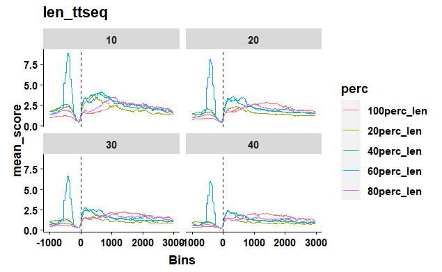

```r
geom6_len_quant <- len_quant |>
  filter( loc == "TSS" & condition == "ctrl" & class_used == "dist") |>
  ggplot( aes( x = Bins, y = mean_score, color = perc)) +
      geom_line() +
      mytheme +
      ggtitle(label="len_ttseq") +
  facet_wrap(~time) +
  geom_vline(xintercept = 0, linetype = "dashed", color = "Black")
geom6_len_quant
```

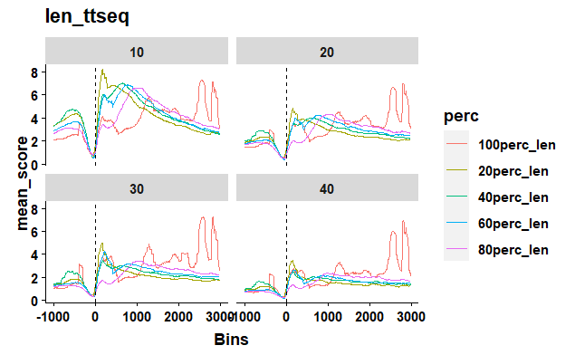

```r
geom7_len_quant <- len_quant |>
  filter( loc == "TSS" & condition == "thoc5" & class_used == "prox") |>
  ggplot( aes( x = Bins, y = mean_score, color = perc)) +
      geom_line() +
      mytheme +
      ggtitle(label="len_ttseq") +
  facet_wrap(~time) +
  geom_vline(xintercept = 0, linetype = "dashed", color = "Black")
geom7_len_quant
```

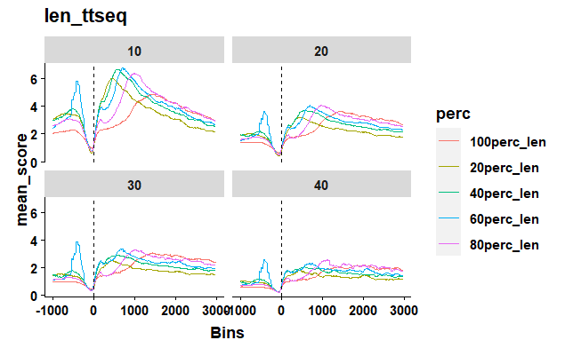

```r
geom8_len_quant <- len_quant |>
  filter( loc == "TSS" & condition == "thoc5" & class_used == "dist") |>
  ggplot( aes( x = Bins, y = mean_score, color = perc)) +
      geom_line() +
      mytheme +
      ggtitle(label="len_ttseq") +
  facet_wrap(~time) +
  geom_vline(xintercept = 0, linetype = "dashed", color = "Black")
geom8_len_quant
```

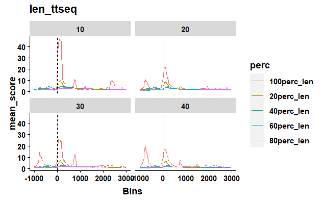

```r
geom9_len_quant <- len_quant |>
  filter( loc == "CGI" & condition == "ctrl" & class_used == "prox") |>
  ggplot( aes( x = Bins, y = mean_score, color = perc)) +
      geom_line() +
      mytheme +
      ggtitle(label="len_ttseq") +
  facet_wrap(~time) +
  geom_vline(xintercept = 0, linetype = "dashed", color = "Black")
geom9_len_quant
```

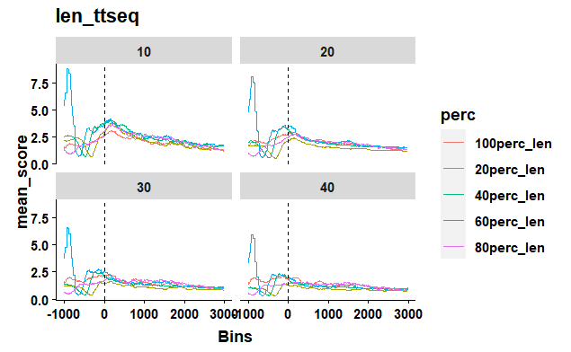

```r
geom10_len_quant <- len_quant |>
  filter( loc == "CGI" & condition == "ctrl" & class_used == "dist") |>
  ggplot( aes( x = Bins, y = mean_score, color = perc)) +
      geom_line() +
      mytheme +
      ggtitle(label="len_ttseq") +
  facet_wrap(~time) +
  geom_vline(xintercept = 0, linetype = "dashed", color = "Black")
geom10_len_quant
```

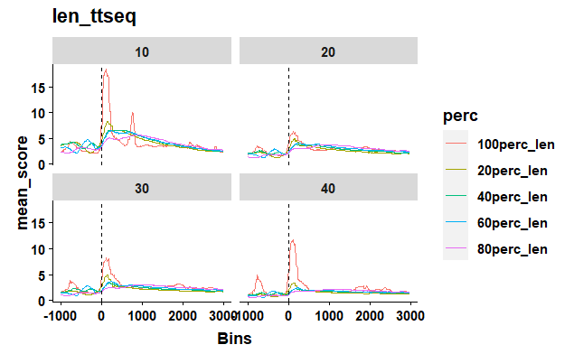

```r
geom11_len_quant <- len_quant |>
  filter( loc == "CGI" & condition == "thoc5" & class_used == "prox") |>
  ggplot( aes( x = Bins, y = mean_score, color = perc)) +
      geom_line() +
      mytheme +
      ggtitle(label="len_ttseq") +
  facet_wrap(~time) +
  geom_vline(xintercept = 0, linetype = "dashed", color = "Black")
geom11_len_quant
```

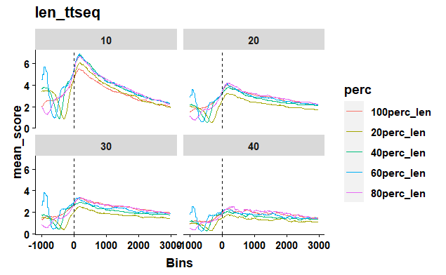

```r
geom12_len_quant <- len_quant |>
  filter( loc == "CGI" & condition == "thoc5" & class_used == "dist") |>
  ggplot( aes( x = Bins, y = mean_score, color = perc)) +
      geom_line() +
      mytheme +
      ggtitle(label="len_ttseq") +
  facet_wrap(~time) +
  geom_vline(xintercept = 0, linetype = "dashed", color = "Black")
geom12_len_quant
```